# Download eurostat

Antonio Avila

03/02/2020

Intro

```r
library(eurostat)

library(httr)
library(jsonlite)
library(tidyverse)
library(plyr)
```

### Download

*TO DO:*

- Review the temporal and geographical reach of each variable of interest for the analysis.
- Data on Turkey is NOT available in Eurostat, but it’s available (partially) in[Wikipedia](https://en.wikipedia.org/wiki/List_of_Turkish_provinces_by_GDP#cite_note-:0-1) and [OECD data](https://stats.oecd.org/#)
  - Regions and Cities > Regional Statistics > Regional Economy > Regional GDP per Capita, OECD.Stats. Accessed on 16 November 2018.
  - “Statistics by Theme > National Accounts > Regional Accounts”. www.turkstat.gov.tr. Retrieved 2019-06-08. And the same for the US!
- Look if lower definitions could help fill up some gaps in a NUTS 3 definition grid.

```r
# http://ropengov.github.io/eurostat/articles/eurostat_tutorial.html
search <- search_eurostat("NUTS 3")
# ?search_eurostat
# search <- rbind(search, search_eurostat("Investment"))
search
```

| title | code | type | last update of data | last table structure change | data start | data end | values |
| --- | --- | --- | --- | --- | --- | --- | --- |
| Area by NUTS 3 region | reg_area3 | dataset | 06.02.2020 | 27.02.2020 | 2013 | 2016 | NA |
| Estimated soil erosion by water, by erosion level, land cover and NUTS 3 regions (source: JRC) | aei_pr_soiler | dataset | 18.12.2019 | 27.02.2020 | 2000 | 2016 | NA |
| Manure storage facilities by NUTS 3 regions | aei_fm_ms | dataset | 05.02.2019 | 27.02.2020 | 2000 | 2010 | NA |
| Structure of agricultural holdings by NUTS 3 regions - main indicators | ef_r_nuts | dataset | 10.09.2009 | 27.02.2020 | 2000 | 2007 | NA |
| Area by NUTS 3 region | demo_r_d3area | dataset | 25.10.2019 | 27.02.2020 | 1990 | 2015 | NA |
| Population density by NUTS 3 region | demo_r_d3dens | dataset | 14.05.2020 | 14.05.2020 | 1990 | 2018 | NA |
| Population on 1 January by age group, sex and NUTS 3 region | demo_r_pjangrp3 | dataset | 14.05.2020 | 14.05.2020 | 2014 | 2019 | NA |
| Population on 1 January by broad age group, sex and NUTS 3 region | demo_r_pjanaggr3 | dataset | 16.06.2020 | 16.06.2020 | 1990 | 2019 | NA |
| Population: Structure indicators by NUTS 3 region | demo_r_pjanind3 | dataset | 17.06.2020 | 17.06.2020 | 2014 | 2019 | NA |
| Population change - Demographic balance and crude rates at regional level (NUTS 3) | demo_r_gind3 | dataset | 14.05.2020 | 14.05.2020 | 2000 | 2019 | NA |

[output cut: 114 more lines]

NOTE of further variables:

- Crimes recorded by the police by NUTS 3 regions
- Income of households by NUTS 2 regions
- Employment in technology and knowledge-intensive sectors by NUTS 2 regions and sex (1994-2008, NACE Rev. 1.1)
- Employment in technology and knowledge-intensive sectors by NUTS 2 regions and sex (from 2008 onwards, NACE Rev. 2)
- Number of local units, persons employed and wages and salaries by NUTS 2 regions from https://ec.europa.eu/eurostat/web/structural-business-statistics/data/database (Nice and many other structural business statistics)
- Causes of death - crude death rate by NUTS 2 region of residence hlth_cd_acdr2 (only from 2011)
- Income of households by NUTS 2 regions

```r
filter_nuts <- function(data, nuts) {
  result <- data %>%
    mutate(geo_char = as.character(geo)) %>%
    filter(nchar(geo_char) == nuts + 2) %>%
    select(-geo_char)
  return(result)
}

eurostat_geodata_60_2016 %>% head()
```

```
Simple feature collection with 6 features and 7 fields
geometry type:  MULTIPOLYGON
dimension:      XY
bbox:           xmin: 2.54601 ymin: 34.56908 xmax: 34.56859 ymax: 51.50246
geographic CRS: WGS 84
  id CNTR_CODE
1 BG        BG
2 CH        CH
3 CY        CY
4 AL        AL
5 CZ        CZ
6 BE        BE
                                                         NUTS_NAME LEVL_CODE
1 БЪЛГАРИЯ         0
2                                          SCHWEIZ/SUISSE/SVIZZERA         0
3                        ΚΥΠΡΟS         0
4                                                        SHQIPËRIA         0
5                                                  CESKÁ REPUBLIKA         0
6                                                 BELGIQUE-BELGIË          0
  FID NUTS_ID                       geometry geo
1  BG      BG MULTIPOLYGON (((22.99717 43...  BG
2  CH      CH MULTIPOLYGON (((8.61383 47....  CH
3  CY      CY MULTIPOLYGON (((33.75237 34...  CY
4  AL      AL MULTIPOLYGON (((19.831 42.4...  AL
5  CZ      CZ MULTIPOLYGON (((14.49122 51...  CZ
6  BE      BE MULTIPOLYGON (((5.10218 51....  BE
```

```r
# Get the total number of regions per conutry and level of NUTS:
tot_number <- eurostat_geodata_60_2016 %>% as.data.frame() %>%
  dplyr::group_by(CNTR_CODE, LEVL_CODE) %>%
  dplyr::summarise(tot_nuts = n())
tot_number
```

| CNTR_CODE | LEVL_CODE | tot_nuts |
| --- | --- | --- |
| AL | 0 | 1 |
| AL | 1 | 1 |
| AL | 2 | 3 |
| AL | 3 | 12 |
| AT | 0 | 1 |
| AT | 1 | 3 |
| AT | 2 | 9 |
| AT | 3 | 35 |
| BE | 0 | 1 |
| BE | 1 | 3 |

[output cut: 138 more lines]

### Create formulas for analysis and understand the data’s limitations:

```r
# An example dataset:
gdp_example <- get_eurostat("nama_10r_3gdp",
  time_format = "num")
```

```
Table nama_10r_3gdp cached at C:\Users\aavil\AppData\Local\Temp\RtmpuIPaAO/eurostat/nama_10r_3gdp_num_code_TF.rds
```

```r
# Filter all other indicators such as "milion units of national currenct or EU %.
gdp_example <- gdp_example %>%
  filter((unit %in% c("MIO_EUR", "EUR_HAB", "MIO_PPS")))

# Calculate the number of regions included in the database per ...
count_gdp <- gdp_example %>%
  mutate(geo_char = as.character(geo)) %>%
  mutate(LEVL_CODE = case_when(
    nchar(geo_char) == 3 + 2 ~ 3,
    nchar(geo_char) == 2 + 2 ~ 2, # France has some extra territorial "colonies", I should look if those (with letters) have a different tratment
    nchar(geo_char) == 1 + 2 ~ 1,
    nchar(geo_char) == 0 + 2 ~ 0,
  ),
  CNTR_CODE = substr(geo_char, 1, 2)) %>% # Get the country code
  filter(substr(geo_char, 3, 3) != "Z") %>% # Avoid the "Extra regions"
  select(-geo_char) %>%
  right_join(tot_number) %>%
  dplyr::group_by(CNTR_CODE, LEVL_CODE, time, unit) %>%
  dplyr::summarise(n_nuts = n(),
                   tot_nuts = max(tot_nuts)) %>%
  mutate(prop = ifelse(is.na(n_nuts), 0, n_nuts/tot_nuts))
count_gdp %>% head()
```

| CNTR_CODE | LEVL_CODE | time | unit | n_nuts | tot_nuts | prop |
| --- | --- | --- | --- | --- | --- | --- |
| AL | 0 | 2008 | EUR_HAB | 1 | 1 | 1 |
| AL | 0 | 2008 | MIO_EUR | 1 | 1 | 1 |
| AL | 0 | 2008 | MIO_PPS | 1 | 1 | 1 |
| AL | 0 | 2009 | EUR_HAB | 1 | 1 | 1 |
| AL | 0 | 2009 | MIO_EUR | 1 | 1 | 1 |
| AL | 0 | 2009 | MIO_PPS | 1 | 1 | 1 |

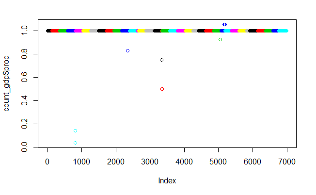

```r
plot(count_gdp$prop, col = factor(count_gdp$CNTR_CODE)) # Algo estoy haciendo mal al contar o en los datos que le doy al contador.
```

```r
# Min and max dates per country
count_gdp %>%
  dplyr::group_by(CNTR_CODE) %>%
  dplyr::summarise(
            time_min = first(time),
            time_max = last(time),
            tot_nuts = max(tot_nuts)
            ) %>%
  arrange(desc(tot_nuts))
```

| CNTR_CODE | time_min | time_max | tot_nuts |
| --- | --- | --- | --- |
| DE | 2000 | 2017 | 401 |
| UK | 2000 | 2018 | 179 |
| IT | 2000 | 2017 | 110 |
| FR | 2015 | 2016 | 101 |
| TR | 2004 | 2018 | 81 |
| PL | 2000 | 2017 | 73 |
| ES | 2000 | 2017 | 59 |
| EL | 2000 | 2017 | 52 |
| BE | 2000 | 2018 | 44 |
| RO | 2000 | 2017 | 42 |

[output cut: 27 more lines]

```r
# count_gdp %>%
#   filter(CNTR_CODE == "FR")
#
# gdp %>% head()

# Function to know data disponibility of Eurostat tables:
s_t_eurostat <- function(data){
  # unique(data$geo)*unique(data$time)
  data %>%
    mutate(geo_char = as.character(geo)) %>%
    mutate(LEVL_CODE = case_when(
      nchar(geo_char) == 3 + 2 ~ 3,
      nchar(geo_char) == 2 + 2 ~ 2,
      nchar(geo_char) == 1 + 2 ~ 1,
      nchar(geo_char) == 0 + 2 ~ 0,
    ),
    CNTR_CODE = substr(geo_char, 1, 2)) %>%
    dplyr::group_by(CNTR_CODE) %>%
    dplyr::summarise(
      time_min = last(time),
      time_max = first(time),
      n_obs = n(),
      prop = (n_obs - sum(is.na(values)))/n_obs
    ) %>%
    arrange(time_min, desc(n_obs))
}

# Function that saves, filters for NUTS 3, and analyses the Eurostat database
down_eurostat <- function(eurostat_str){
  name_df <- get_eurostat(eurostat_str,
                           time_format = "num")
  name_df %>% head() %>% print()
  s_t_eurostat(name_df) %>% print()
  # name_df <- filter_nuts(name_df, 3)
  return(name_df)
}

# list_euro_data <- c("nama_10r_3gdp", "nama_10r_3gva")
```

Note:

- It would be good to review the reason of the 7-10 deviations we see on the graph.
- data has some “extra regions NUTS X{1,2,3}” in some countries and one for NUTS level. They account for extra regions (maritimal spaces, air space, and are optionals for countries to report) but have as third, fourth and 5th letter a Z instead of a number.
- All NUTS regions of the same country start the same year, but some “NUTS 2 or 1” have data from 2017 while other NUTS3 have only until 2016
- France and Poland are the biggest “holes” in the data.

Get the GDP

```r
# Gross domestic product (GDP) at current market prices by NUTS 3 regions
down_eurostat("nama_10r_3gdp") -> e_gdp
```

```
Reading cache file C:\Users\aavil\AppData\Local\Temp\RtmpAf3h4e/eurostat/nama_10r_3gdp_num_code_TF.rds
Table  nama_10r_3gdp  read from cache file:  C:\Users\aavil\AppData\Local\Temp\RtmpAf3h4e/eurostat/nama_10r_3gdp_num_code_TF.rds
```

| unit | geo | time | values |
| --- | --- | --- | --- |
| EUR_HAB | AT | 2018 | 43600 |
| EUR_HAB | AT1 | 2018 | 43100 |
| EUR_HAB | AT11 | 2018 | 30700 |
| EUR_HAB | AT12 | 2018 | 36500 |
| EUR_HAB | AT13 | 2018 | 51000 |
| EUR_HAB | AT2 | 2018 | 39100 |

| CNTR_CODE | time_min | time_max | n_obs | prop |
| --- | --- | --- | --- | --- |
| DE | 2000 | 2018 | 90893 | 1 |
| UK | 2000 | 2018 | 48925 | 1 |
| IT | 2000 | 2018 | 27647 | 1 |
| ES | 2000 | 2018 | 17409 | 1 |
| EL | 2000 | 2018 | 14058 | 1 |
| BE | 2000 | 2018 | 12559 | 1 |
| NL | 2000 | 2018 | 11676 | 1 |
| RO | 2000 | 2018 | 11257 | 1 |
| AT | 2000 | 2018 | 9871 | 1 |
| PT | 2000 | 2018 | 7473 | 1 |

[output cut: 25 more lines]

```r
e_gdp <- e_gdp %>%
  filter((unit %in% c("MIO_EUR", "EUR_HAB", "MIO_PPS")))


# Filter all other indicators such as "milion units of national currenct or EU %.
e_gdp$unit %>% table()
```

```
.
          EUR_HAB        EUR_HAB_EU EUR_HAB_EU27_2020           MIO_EUR
            31875                 0                 0             32765
          MIO_NAC           MIO_PPS MIO_PPS_EU27_2020 PPS_EU27_2020_HAB
                0             32765                 0                 0
          PPS_HAB        PPS_HAB_EU PPS_HAB_EU27_2020
                0                 0                 0
```

```r
e_gdp %>% filter(unit == "EUR_HAB", geo == "FR101")
```

| unit | geo | time | values |
| --- | --- | --- | --- |
| EUR_HAB | FR101 | 2016 | 97900 |
| EUR_HAB | FR101 | 2015 | 96600 |

```r
# Note: We have only data until 2016 for france!
e_gdp %>% head()
```

| unit | geo | time | values |
| --- | --- | --- | --- |
| EUR_HAB | AT | 2018 | 43600 |
| EUR_HAB | AT1 | 2018 | 43100 |
| EUR_HAB | AT11 | 2018 | 30700 |
| EUR_HAB | AT12 | 2018 | 36500 |
| EUR_HAB | AT13 | 2018 | 51000 |
| EUR_HAB | AT2 | 2018 | 39100 |

```r
# write.csv(gdp, file = "eurostat_gdp.csv")

# Gross value added at basic prices by NUTS 3 regions
down_eurostat("nama_10r_3gva") -> e_gva
```

```
Table nama_10r_3gva cached at C:\Users\aavil\AppData\Local\Temp\RtmpAf3h4e/eurostat/nama_10r_3gva_num_code_TF.rds
```

| currency | nace_r2 | geo | time | values |
| --- | --- | --- | --- | --- |
| MIO_EUR | A | AL | 2018 | 2364.14 |
| MIO_EUR | A | AL0 | 2018 | 2364.14 |
| MIO_EUR | A | AL01 | 2018 | 670.20 |
| MIO_EUR | A | AL011 | 2018 | 144.35 |
| MIO_EUR | A | AL012 | 2018 | 169.96 |
| MIO_EUR | A | AL013 | 2018 | 67.97 |

| CNTR_CODE | time_min | time_max | n_obs | prop |
| --- | --- | --- | --- | --- |
| IT | 1995 | 2018 | 80158 | 1 |
| PT | 1995 | 2018 | 25280 | 1 |
| CZ | 1995 | 2018 | 16580 | 1 |
| EE | 1995 | 2018 | 5760 | 1 |
| LU | 1995 | 2018 | 2880 | 1 |
| DE | 2000 | 2018 | 145318 | 1 |
| UK | 2000 | 2018 | 133532 | 1 |
| EL | 2000 | 2018 | 37836 | 1 |
| BE | 2000 | 2018 | 33972 | 1 |
| ES | 2000 | 2018 | 33810 | 1 |

[output cut: 24 more lines]

```r
e_gva <- e_gva %>%
  filter(currency == "MIO_EUR")

# Note: We have only data until 2016 for france!
e_gva %>% filter(nace_r2 == "J", geo == "FR101")
```

| currency | nace_r2 | geo | time | values |
| --- | --- | --- | --- | --- |
| MIO_EUR | J | FR101 | 2016 | 24744.06 |
| MIO_EUR | J | FR101 | 2015 | 22244.08 |

```r
write.csv(e_gva, file = "data/eurostat/eurostat_gva.csv")
```

Dechelepètre deflates gdp using country-level Eurostat GDP deflator

> Regional accounts according to ESA2010 is available as from the reference year 2000 with a few exceptions. Countries that were affected by changes in the NUTS 2016 classification are only legally obliged to provide data in NUTS 2016 for the most recent year, historical series can be reported until December 2019. This particularly affects *Poland, France and Lithuania*. Historical series for the Netherlands are also missing due to a benchmark revision to their National Accounts.

Note: I need to find the old data. France nuts 3 has NOT changed, Poland has changed and Lithuania (i don’t know)

Get Employment

```r
# Employment (thousand persons) by NUTS 3 regions
down_eurostat("nama_10r_3empers") -> e_emp
```

```
Table nama_10r_3empers cached at C:\Users\aavil\AppData\Local\Temp\RtmpAf3h4e/eurostat/nama_10r_3empers_num_code_TF.rds
```

| unit | wstatus | nace_r2 | geo | time | values |
| --- | --- | --- | --- | --- | --- |
| THS | EMP | A | BE | 2018 | 58.7 |
| THS | EMP | A | BE1 | 2018 | 0.1 |
| THS | EMP | A | BE10 | 2018 | 0.1 |
| THS | EMP | A | BE100 | 2018 | 0.1 |
| THS | EMP | A | BE2 | 2018 | 40.7 |
| THS | EMP | A | BE21 | 2018 | 9.2 |

| CNTR_CODE | time_min | time_max | n_obs | prop |
| --- | --- | --- | --- | --- |
| IT | 1995 | 2018 | 80129 | 1 |
| PT | 1995 | 2018 | 25267 | 1 |
| CZ | 1995 | 2018 | 16570 | 1 |
| EE | 1995 | 2018 | 5040 | 1 |
| LU | 1995 | 2018 | 2880 | 1 |
| DE | 2000 | 2018 | 145243 | 1 |
| UK | 2000 | 2018 | 133532 | 1 |
| EL | 2000 | 2018 | 37818 | 1 |
| BE | 2000 | 2018 | 34020 | 1 |
| ES | 2000 | 2018 | 33810 | 1 |

[output cut: 22 more lines]

```r
# emp <- filter_nuts(employment, 3)
e_emp$geo %>% unique() %>% length()
```

```
[1] 1766
```

```r
# # Change values for NACE activities
# e_emp <- e_emp %>%
#   mutate(nace = revalue(nace_r2,
#     c("A" = "Agriculture, forestry and fishing",
#       "B-E" = "Industry (except construction)",
#       "C" = "Manufacturing",
#       "F" = "Construction",
#       "G-J" = "Wholesale and retail trade; transport; accommodation and food service activities; information and communication",
#       "G-I" = "Wholesale and retail trade, transport, accommodation and food service activities",
#       "J" = "Information and communication",
#       "K-N" = "Financial and insurance activities; real estate activities; professional, scientific and technical activities; administrative and support service a...",
#       "K" = "Real estate activities",
#       "M_N" = "Professional, scientific and technical activities; administrative and support service activities",
#       "O-U" = "Public administration and defence; compulsory social security; education; human health and social work activities; arts, entertainment and recreati...",
#       "O-Q" = "Public administration, defence, education, human health and social work activities",
#       "R-U" = "Arts, entertainment and recreation; other service activities; activities of household and extra-territorial organizations and bodies")))

# e_emp <- e_emp %>%
#   mutate(
#     wstatus = revalue(
#       wstatus,
#       c("EMP" = "Employed persons", # Person 15y+ (or 16y+ in Iceland and Norway) who during the reference week performed +1h of work for pay, profit or family gain.
#         "SAL" = "Employees"))) # Person with contract to work for employer and receives compensation

head(e_emp)
```

| unit | wstatus | nace_r2 | geo | time | values |
| --- | --- | --- | --- | --- | --- |
| THS | EMP | A | BE | 2018 | 58.7 |
| THS | EMP | A | BE1 | 2018 | 0.1 |
| THS | EMP | A | BE10 | 2018 | 0.1 |
| THS | EMP | A | BE100 | 2018 | 0.1 |
| THS | EMP | A | BE2 | 2018 | 40.7 |
| THS | EMP | A | BE21 | 2018 | 9.2 |

```r
summary(e_emp)
```

```
  unit        wstatus         nace_r2            geo              time
 THS:752852   EMP:379613   TOTAL  : 59454   EE     :   720   Min.   :1995
              SAL:373239   O-U    : 59054   EE0    :   720   1st Qu.:2004
                           F      : 58634   EE00   :   720   Median :2009
                           C      : 58586   EE001  :   720   Mean   :2009
                           G-J    : 58442   EE008  :   720   3rd Qu.:2013
                           K-N    : 58442   LU     :   720   Max.   :2018
                           (Other):400240   (Other):748532
     values
 Min.   :     0.00
 1st Qu.:     4.68
 Median :    16.80
 Mean   :   108.67
 3rd Qu.:    56.20
 Max.   :239095.01
```

```r
colSums(is.na(e_emp))
```

```
   unit wstatus nace_r2     geo    time  values
      0       0       0       0       0       0
```

```r
write.csv(e_emp, file = "data/eurostat/eurostat_employment.csv")

## Also data of labor market by city (with missing data) (see also "urb_clma")
# https://appsso.eurostat.ec.europa.eu/nui/show.do?dataset=urb_llma&lang=en
```

- Look at unemployment statistscs (and others) of “cities” as here: https://ec.europa.eu/eurostat/cache/RCI/#?vis=city.statistics&lang=en https://ec.europa.eu/eurostat/web/cities/data/database
- I would like to know the geografical definition of the city that builds these statistics. Is it the LAU definition? The functional urban areas?

Compensation of employees (SAL, not EMP) (wages) by NACE activity EU NUTS 2 - 2000 2017 1 year Eurostat nama_10r_2coe - Million euros

*PROBLEMS WITH FRANCE*

```r
Comp_emp_Nace_N2$currency %>% table()
```

```
.
MIO_EUR MIO_NAC
 111226       0
```

Hours worked by NUTS 2 regions:

*NOTE: France and Poland have MISSING*

```r
# 1000s Hours Worked by NACE activity   EU  NUTS 2  1980    2015    1 year  Eurostat, AMECO, OECD

down_eurostat("nama_10r_2emhrw") -> emp_h_workN2
```

```
Reading cache file C:\Users\aavil\AppData\Local\Temp\RtmpuIPaAO/eurostat/nama_10r_2emhrw_num_code_TF.rds
Table  nama_10r_2emhrw  read from cache file:  C:\Users\aavil\AppData\Local\Temp\RtmpuIPaAO/eurostat/nama_10r_2emhrw_num_code_TF.rds
```

| unit | wstatus | nace_r2 | geo | time | values |
| --- | --- | --- | --- | --- | --- |
| THS | EMP | A | CY | 2018 | 43858.48 |
| THS | EMP | A | CY0 | 2018 | 43858.48 |
| THS | EMP | A | CY00 | 2018 | 43858.48 |
| THS | EMP | A | DK | 2018 | 98952.00 |
| THS | EMP | A | DK0 | 2018 | 98952.00 |
| THS | EMP | A | DK01 | 2018 | 4822.00 |

| CNTR_CODE | time_min | time_max | n_obs | prop |
| --- | --- | --- | --- | --- |
| PT | 1995 | 2017 | 7866 | 1 |
| CZ | 1995 | 2017 | 6900 | 1 |
| LU | 1995 | 2018 | 2160 | 1 |
| UK | 2000 | 2018 | 31920 | 1 |
| DE | 2000 | 2017 | 29700 | 1 |
| ES | 2000 | 2018 | 16530 | 1 |
| IT | 2000 | 2016 | 14790 | 1 |
| NL | 2000 | 2017 | 10260 | 1 |
| EL | 2000 | 2017 | 9720 | 1 |
| BE | 2000 | 2017 | 8316 | 1 |

[output cut: 19 more lines]

```r
write.csv(emp_h_workN2, "data/eurostat/hours_worked_nuts2.csv")

# emp_h_workN2 %>%
#   # filter(substr(geo, 1, 2) == "DE") %>%
#   filter(geo == "BG34")
```

Investment in capital per NUTS 2 region: (in million euros) > ! France, NO and DE have less data of investment

| nace_r2 | geo | time | values |
| --- | --- | --- | --- |
| A | CY | 2018 | 30.61 |
| A | CY0 | 2018 | 30.61 |
| A | CY00 | 2018 | 30.61 |
| A | EE | 2018 | 326.90 |
| A | EE0 | 2018 | 326.90 |
| A | EE00 | 2018 | 326.90 |
| A | LU | 2018 | 141.38 |
| A | LU0 | 2018 | 141.38 |
| A | LU00 | 2018 | 141.38 |
| A | MT | 2018 | 24.03 |

[output cut: 990 more lines]

## GDP, GVA and employment for France, Poland, and others who did not had it:

```r
investment_capital_nuts2 %>%
  mutate(CNTR_CODE = substr(geo, 1, 2) %>% as.factor()) %>%
  # filter(CNTR_CODE == "FR") %>% select(time) %>% table()
  select(CNTR_CODE) %>% table()
```

```
.
   AT    BE    BG    CY    CZ    DE    DK    EE    EL    ES    FI    FR    HR
 4050  4158  2430   855  3450 13200  2430  1080  4860  7830  2276  1320  1080
   HU    IE    IT    LT    LU    LV    MK    MT    NL    NO    PL    PT    RO
 3780  1350 10005  1080  1080   810   765  1800  5130  1560  6750  3147  3510
   SE    SI    SK    UK
 3240  1080  1620 15960
```

1. Get the old data:

| currency | nace_r2 | geo | time | obs_value |
| --- | --- | --- | --- | --- |
| MIO_EUR | J | BE1 | 2011 | 1204.2 |
| MIO_NAC | K-N | BE1 | 2012 | 4432.0 |
| MIO_EUR | K-N | BE1 | 2012 | 4432.0 |
| MIO_NAC | G-J | BE1 | 2012 | 3651.8 |
| MIO_EUR | G-J | BE1 | 2012 | 3651.8 |
| MIO_NAC | O-U | BE1 | 2012 | 2172.6 |

2. filter and review it is complete:

```r
table((old_hours2 %>% dplyr::filter(CNTR_CODE == "PL"))$time) # %>% plot(type = 'l') # ! This is almost useless
```

```
2008 2009 2010 2011 2012 2013 2014 2015
 690  690  690  690  690  690  690  690
```

| Code 2013 | Code 2016 | currency | nace_r2 | time | obs_value | CNTR_CODE | geo |
| --- | --- | --- | --- | --- | --- | --- | --- |
| FR26 | FRC1 | MIO_EUR | L | 2008 | 240.3 | FR | FRC1 |
| FR26 | FRC1 | MIO_EUR | J | 2008 | 323.9 | FR | FRC1 |
| FR26 | FRC1 | MIO_EUR | G-I | 2008 | 4566.8 | FR | FRC1 |
| FR26 | FRC1 | MIO_EUR | A | 2008 | 357.7 | FR | FRC1 |
| FR26 | FRC1 | MIO_EUR | C | 2008 | 3849.8 | FR | FRC1 |
| FR26 | FRC1 | MIO_EUR | K-N | 2008 | 2995.6 | FR | FRC1 |

Tests and ideas on how the changes in NUTS 3 regions affect the statistics of GDP:

```r
# EXAMPLE BOUNDARY SHIFT: ¿IS a good idea to include also territories that have "small" bounday shifts?

# I have to decide if I exclude from the dataset the NUTS that have had bounday shifts but that Eurostat has a continuous series for them. I don't know if they ar OK or not.
# -->  Look if they have the same data (Look at Belfast, that has a boundary change)):

old_gdp %>% filter(geo == "UKN01", # Old belfast
                   unit == "MIO_EUR") %>%
  select(unit, geo, time, obs_value) %>%
  left_join(y = e_gdp %>% filter(geo == "UKN06", # New belfast
                   unit == "MIO_EUR"), by = "time")

# Note: There are BIG disparities between both statistics even if the territory of the NUTS 3 increases just a bit.
# Conclusion: I would not include it if there was no previous data. Given is Eurostat who is "creating" the previous data I feel confident about it.

# EXAMPLE SIMPLE REDIFINITION OF NAME:
# Look if France 2015 in old data is the same as 2015 in new data:

old_gdp %>% filter(geo == "FR711", # Old Ain
                   unit == "MIO_EUR") %>%
  select(unit, geo, time, obs_value) %>%
  full_join(y = e_gdp %>% filter(geo == "FRK21", # New Ain (France)
                   unit == "MIO_EUR"), by = "time")

# Note: Values for 2015 are between a 3-5% change (a 3-5% increase in GDP that is not justified!) and I only get 1 year more of data. Does the same happens with Paris?

old_gdp %>% filter(geo == "FR101", # Old Paris
                   unit == "MIO_EUR") %>%
  select(unit, geo, time, obs_value) %>%
  full_join(y = e_gdp %>% filter(geo == "FR101", # New Paris (France)
                   unit == "MIO_EUR"), by = "time")

# The `unjustified` growth of Paris is of a 0.15%
100*(212410.4-212091)/212091

# Differences all arround (for MIO_EUR)
old_gdp %>% filter(unit == "MIO_EUR") %>%
  select(unit, geo, time, obs_value) %>%
  full_join(y = e_gdp %>% filter(unit == "MIO_EUR"), by = c("geo", "time")) %>%
  mutate(increase = 100*(values-obs_value)/obs_value) -> test_change

mean(test_change$increase, na.rm = TRUE)
hist(test_change$increase, breaks = 50, xlim = c(-10, 10))
# Note: there are some very big changes, should I discard them from the data?
```

Join France and Poland 2000-2014 for now (other ountries can wait) I AM ONLY JOINING FRANCE AND POLAND? - I think I am joining all of it.

```r
# GDP
old_gdp_new_codes %>%
  #filter(time < 2015) %>% # Exclude 2015
  full_join(e_gdp) %>%  #filter(geo == "FRK21", unit == "MIO_EUR")  %>% # New Ain (France, example)
  mutate(values = ifelse(test = is.na(values),
                         yes = obs_value,
                         no = values),
         CNTR_CODE = substr(geo, 1, 2)) %>%
  select(unit, time, geo, values, CNTR_CODE) -> e_gdp_complete
# GVA
old_gva_new_codes %>%
  #filter(time < 2015) %>% # Exclude 2015
  full_join(e_gva) %>%  # filter(geo == "FRK21", nace_r2 == "J") # %>% # New Ain (France, example)
  mutate(values = ifelse(test = is.na(values), # If there is no "new data"
                         yes = obs_value, # Take old data
                         no = values),
         CNTR_CODE = substr(geo, 1, 2)) %>%
  select(nace_r2, time, geo, values, CNTR_CODE) -> e_gva_complete
# EMP employment
old_emp_new_codes %>%
  #filter(time < 2015) %>% # Exclude 2015
  full_join(e_emp) %>% # filter(geo == "FRK21", nace_r2 == "J") # %>% # New Ain (France, example)
  mutate(values = ifelse(test = is.na(values), # If there is no "new data"
                         yes = obs_value, # Take old data
                         no = values),
         CNTR_CODE = substr(geo, 1, 2)) %>%
  select(wstatus, nace_r2, time, geo, values, CNTR_CODE) -> e_emp_complete
# WAGES (Compensation for employees)

Comp_emp_Nace_N2_complete <- old_wages_new_codes %>%
  #filter(time < 2015) %>% # Exclude 2015
  full_join(Comp_emp_Nace_N2) %>% # filter(geo == "FRK21", nace_r2 == "J") # %>% # New Ain (France, example)
  mutate(values = ifelse(test = is.na(values), # If there is no "new data"
                         yes = obs_value, # Take old data
                         no = values),
         CNTR_CODE = substr(geo, 1, 2)) %>%
  select(currency, nace_r2, time, geo, values, CNTR_CODE)
# Review I now have data for all the years (yes!)
e_gdp_complete %>%
  dplyr::group_by(as.character(CNTR_CODE)) %>%
  arrange(desc(time)) %>%
  dplyr::summarise(
    time_min = last(time),
    time_max = first(time),
    n_obs = n()
  ) %>%
  arrange(time_min, desc(n_obs))
```

| as.character(CNTR_CODE) | time_min | time_max | n_obs |
| --- | --- | --- | --- |
| DE | 2000 | 2018 | 24981 |
| UK | 2000 | 2018 | 13752 |
| IT | 2000 | 2018 | 7591 |
| FR | 2000 | 2018 | 7484 |
| PL | 2000 | 2018 | 5394 |
| ES | 2000 | 2018 | 4817 |
| EL | 2000 | 2018 | 3834 |
| NL | 2000 | 2018 | 3574 |
| BE | 2000 | 2018 | 3477 |
| RO | 2000 | 2018 | 3121 |

[output cut: 25 more lines]

```r
e_emp_complete %>%
  dplyr::group_by(as.character(CNTR_CODE)) %>%
  arrange(desc(time)) %>%
  dplyr::summarise(
    time_min = last(time),
    time_max = first(time),
    n_obs = n()
  ) %>%
  arrange(time_min, desc(n_obs))
```

| as.character(CNTR_CODE) | time_min | time_max | n_obs |
| --- | --- | --- | --- |
| IT | 1995 | 2018 | 80129 |
| PT | 1995 | 2018 | 25267 |
| CZ | 1995 | 2018 | 16570 |
| EE | 1995 | 2018 | 5550 |
| LU | 1995 | 2018 | 2880 |
| DE | 2000 | 2018 | 146267 |
| UK | 2000 | 2018 | 133566 |
| FR | 2000 | 2018 | 65641 |
| PL | 2000 | 2018 | 50852 |
| EL | 2000 | 2018 | 37818 |

[output cut: 22 more lines]

```r
Comp_emp_Nace_N2_complete %>%
  dplyr::group_by(as.character(CNTR_CODE)) %>%
  arrange(desc(time)) %>%
  dplyr::summarise(
    time_min = last(time),
    time_max = first(time),
    n_obs = n()
  ) %>%
  arrange(time_min, desc(n_obs))
```

| as.character(CNTR_CODE) | time_min | time_max | n_obs |
| --- | --- | --- | --- |
| IT | 1995 | 2017 | 10005 |
| PT | 1995 | 2017 | 3933 |
| CZ | 1995 | 2017 | 3450 |
| MT | 1995 | 2018 | 1800 |
| EE | 1995 | 2018 | 1080 |
| LU | 1995 | 2018 | 1080 |
| UK | 2000 | 2018 | 16458 |
| DE | 2000 | 2017 | 14850 |
| ES | 2000 | 2018 | 8265 |
| PL | 2000 | 2017 | 6720 |

[output cut: 20 more lines]

```r
write.csv(e_gdp_complete, file = "data/eurostat/eurostat_gdp_complete.csv")
write.csv(e_gva_complete, file = "data/eurostat/eurostat_gva_complete.csv")
write.csv(e_emp_complete, file = "data/eurostat/eurostat_emp_complete.csv")
write.csv(Comp_emp_Nace_N2_complete,
          "data/eurostat/compensation_emp_nace_n2_complete.csv")
## France -> No NUTS 3 problems (¿)
## Poland -> Review NUTS 3 changes

e_emp_complete %>% head()
```

| wstatus | nace_r2 | time | geo | values | CNTR_CODE |
| --- | --- | --- | --- | --- | --- |
| SAL | O-Q | 2000 | IE042 | 30.65 | IE |
| SAL | J | 2000 | IE042 | 3.48 | IE |
| SAL | A | 2000 | IE042 | 2.41 | IE |
| SAL | M_N | 2000 | IE042 | 6.05 | IE |
| SAL | L | 2000 | IE042 | 0.39 | IE |
| SAL | K | 2000 | IE042 | 3.04 | IE |

```r
# e_emp_complete$nace_r2 %>% table()
```

```r
# [ ] Review if I am including cases with boundary shifts such as Belfast
# -> Yes but they seem to have solved (or predicted) the issue and have data corresponding to the new geography:

# e_gdp_complete %>%
#   filter(geo == "UKN06", unit == "MIO_EUR")
```

NUTS 1 (Region) GDP data for france is Here: France: PIBR (regional PIB piblished by INSEE) * https://www.insee.fr/fr/statistiques/1893220 (new and old regions. Maybe I can lay with those to create a “finer” grain of definition?) * https://statistiques-locales.insee.fr/#c=indicator&i=tcr062.pib_brut&i2=tcr062.pib_hab&s=2015&s2=2015&view=map3 (all NUTS 1 statistics)

- https://statistiques-locales.insee.fr/#c=zonage (all regions and dub-divisions of france) France has some extra territorial “colonies”, I should look if those (with letters) have a different tratment

Comune (municipality, smaller to nuts 3) –> https://www.insee.fr/fr/recherche/recherche-statistiques?q=produits+interieurs&taille=100&debut=0&idprec=1893206&theme=27&categorie=1&geo=TOUTES_COMMUNE-1 * Jobs by sector (only 1982, 1990, 1999, 2006, 2011, 2016) * Jobs by type of sector (same years)

Unemployment rate/persons EU NUTS 4 (metropolitan area) (imperfect)

```r
down_eurostat("met_lfu3pers") -> unemp_pers_N4
down_eurostat("met_lfu3rt") -> unemp_rate_N4
```

- Unemployment by sex, age, country of birth and NUTS 2 regions (imperfect but improvable) - Thousands persons

(Big source of labor data: https://ec.europa.eu/eurostat/web/lfs/data/database (LFS Regional series))

```r
down_eurostat("lfst_r_lfu2gac") -> unemp_age_origin

# Check if I have unemployment of the most common case for the most important years
for (i in unique(unemp_age_origin$c_birth)){ # for each type of origin
unemp_age_origin %>%
  filter(sex == "T",
         age == "Y15-74",
         time <= 2018,
         time >= 2000,
         c_birth == i,
         # possibles: TOTAL (good), EU15_FOR (acceptable), FOR (good), NAT (v_good)
         nchar(as.character(geo)) >= 4
         ) %>%
  s_t_eurostat() %>%
  # join with the real number of nuts and calculate the proportion of values in the data
  left_join(tot_number %>%
              filter(LEVL_CODE == 2) %>%
              mutate(tot_nuts_n = tot_nuts*19)) %>% # 16 = number of years
  mutate(prop = n_obs/tot_nuts_n) %>%
    print()
  print(i)
}

# Restrict to set of more relevant paramenters:
unemp_age_origin <- unemp_age_origin %>%
  filter(age == "Y15-74", # "Y25-54" and "Y55-64" also look interesting
         time <= 2018,
         time >= 2000,
         c_birth %in% c("TOTAL","EU15_FOR", "NEU15_FOR", "FOR", "NAT")
         #nchar(as.character(geo)) >= 4
         )

unemp_age_origin %>% head()

# write.csv(unemp_age_origin, "data/eurostat/unemp_age_origin_nuts2.csv")
```

```r
down_eurostat("lfst_r_lfu3rt") -> unemp_r_age

# Chek there is enough data:
unemp_r_age %>%
  filter(sex == "T",
         age == "Y15-74",
         time <= 2018,
         time >= 2000,
         # possibles: TOTAL (good), EU15_FOR (acceptable), FOR (good), NAT (v_good)
         nchar(as.character(geo)) >= 4
         ) %>%
  s_t_eurostat() %>%
  # join with the real number of nuts and calculate the proportion of values in the data
  left_join(tot_number %>%
              filter(LEVL_CODE == 2) %>%
              mutate(tot_nuts_n = tot_nuts*18)) %>% # 16 = number of years
  mutate(prop = n_obs/tot_nuts_n)

# Restrict to set of more relevant paramenters:
temp <- unemp_r_age %>%
  filter(age == "Y15-74", # "Y25-54" and "Y55-64" also look interesting
         time <= 2018,
         time >= 2000
         )

temp %>% head()

# write.csv(temp, "data/eurostat/unemprate_age_sex_nuts2.csv")
```

Total and active population by sex, age, employment status, residence one year prior to the census and NUTS 3 regions

```r
down_eurostat("cens_01ramigr") -> act_pop_2001
```

Economically active population by sex, age and NUTS 2 regions - 1000s - 1999 2019 1 year - GE15 -> 15 years or over

```r
down_eurostat("lfst_r_lfp2act") -> ActPop_age_N2

# write.csv(ActPop_age_N2, "data/eurostat/active_pop_age_sex_N2.csv")
```

Economically active population by sex and age EU Metropolitan Regions 2002 2018 1 year Eurostat (imperfect)

```r
down_eurostat("met_lfp3pop") -> ActPop_age_Metro
```

Science and tech Statistics:

```r
# Patent applications to the EPO by priority year by NUTS 3 regions - pat_ep_rtot
# Patent applications to the EPO by priority year by NUTS 3 regions, international patent classification (IPC) sections and classes  - pat_ep_rtec
# High-tech patent applications to the EPO by priority year by NUTS 3 regions
# European Union trade mark (EUTM) applications by NUTS 3 regions   - ipr_ta_reg


down_eurostat("ipr_da_reg") -> cd_appl
# write.csv(cd_appl, file = "data/eurostat/eurostat_cd_appl.csv")

###
down_eurostat("pat_ep_rtot")  -> e_patent_epo
table(e_patent_epo$unit)
write.csv(e_patent_epo, file = "data/eurostat/eurostat_patent_epo.csv")
```

Demografic Statistics:

```r
#  total average pop to calculate gdp
# (INCOMPLETE FRANCE AND OTHERS) -> # demo_r_pjanaggr3 (below) solves it

# down_eurostat("nama_10r_3popgdp")  -> e_pop_gdp
# write.csv(e_pop_gdp, file = "data/eurostat/eurostat_pop_gdp.csv")


down_eurostat("demo_r_births")  -> e_births
write.csv(e_births, file = "data/eurostat/eurostat_births.csv")

# # Only from 2013!!
# down_eurostat("demo_r_find3")  -> e_fert
# table(e_fert$indic_de)
# write.csv(e_fert, file = "data/eurostat/eurostat_fert.csv")

down_eurostat("demo_r_deaths")  -> e_deaths
write.csv(e_deaths, file = "data/eurostat/eurostat_deaths.csv")

# # Population: Structure indicators by NUTS 3 region
# # ONLY FROM 2014!
# down_eurostat("demo_r_pjanind3") -> e_pop_ind
# table(e_pop_ind$indic_de)
# write.csv(e_pop_ind, file = "data/eurostat/eurostat_pop_ind_2014.csv")
#
# # demo_r_pjangrp3 pop by age group
# down_eurostat("demo_r_pjangrp3") -> e_pop_age
# e_pop_age$age %>% table()
# write.csv(e_pop_age, file = "data/eurostat/eurostat_pop_age_2014.csv")

# demo_r_pjanaggr3 pop by broad age group
down_eurostat("demo_r_pjanaggr3") -> e_pop_age_aggr
e_pop_age_aggr$age %>% table()
write.csv(e_pop_age_aggr, file = "data/eurostat/eurostat_pop_age_aggr.csv")

# Dependency ratio
# "https://urban.jrc.ec.europa.eu/#/en/download"

# Population by single year of age and NUTS 3 region (only 2001 and 2011)
## This should be already included in the dependenct ratio from demo_r_pjanind3.
# down_eurostat("cens_11ag_r3") -> e_pop_age_11

down_eurostat("cens_01rapop") -> e_pop_age_01
write.csv(e_pop_age_01, file = "data/eurostat/eurostat_cens_01rapop.csv")

# demo_r_d3dens density
down_eurostat("demo_r_d3dens") -> e_pop_dens
e_pop_dens %>% head()
write.csv(e_pop_dens, file = "data/eurostat/eurostat_dens.csv")
```

### Education:

```r
# cens_01rews pop by age, sex and educational attainment level ONLY 2001
down_eurostat("cens_01rews") -> e_pop_educ_2001
e_pop_educ_2001$isced97 %>% table()
write.csv(e_pop_educ_2001, file = "data/eurostat/eurostat_pop_educ_2001.csv")

#- Pop aged 25-64 by educ level, sex and NUTS 2 regions (%) - edat_lfse_04
#- Pop aged 30-34 by educ level, sex and NUTS 2 regions (%) - edat_lfse_12
down_eurostat("edat_lfse_04") -> e_pop_educ_nuts2
rbind(e_pop_educ_nuts2,
      down_eurostat("edat_lfse_12")) -> e_pop_educ_nuts2
summary(e_pop_educ_nuts2)
write.csv(e_pop_educ_nuts2, file = "data/eurostat/eurostat_pop_educ_NUTS2.csv")

# https://appsso.eurostat.ec.europa.eu/nui/show.do?dataset=urb_ceduc&lang=en
get_eurostat("urb_ceduc") -> e_urb_ceduc
e_urb_ceduc$indic_ur %>% table()
# With missing data

# https://appsso.eurostat.ec.europa.eu/nui/show.do?dataset=urb_leduc&lang=en
get_eurostat("urb_leduc") -> e_urb_leduc

e_urb_leduc <- e_urb_leduc %>%
  filter(indic_ur %in% c("TE2025V", "TE2028V", "TE2031V"))
# With missing data
e_pop_educ_2001
```

*Note*:It is possible to have the GEOSTAT population grid from 2006 and 2011.

Business Demography:

```r
# Business demography and high growth enterprise by NACE Rev. 2 and NUTS 3 regions

down_eurostat("bd_hgnace2_r3") -> e_bd_growth_nace
write.csv(e_bd_growth_nace, "data/eurostat/eurostat_bd_growth_nace_2008.csv")
# Business demography by size class and NUTS 3 regions  bd_size_r3

down_eurostat("bd_size_r3") -> e_bd_growth_size
write.csv(e_bd_growth_size, "data/eurostat/eurostat_bd_growth_size_2008.csv")

# Employer business demography by NACE Rev. 2 and NUTS 3 regions

down_eurostat("bd_enace2_r3") -> e_bd_employer_nace_2008

write.csv(e_bd_employer_nace_2008,
          "data/eurostat/eurostat_bd_employer_nace_2008.csv")

# Employer business demography by size class and NUTS 3 regions bd_esize_r3
down_eurostat("bd_esize_r3") -> e_bd_employer_size_2008
write.csv(e_bd_employer_size_2008,
          "data/eurostat/eurostat_bd_employer_size_2008.csv")

# read.csv("data/eurostat/eurostat_bd_employer_nace_2008.csv")
# read.csv("data/eurostat/eurostat_bd_growth_size_2008.csv")
```

### Envirnonment:

```r
# https://appsso.eurostat.ec.europa.eu/nui/show.do?dataset=urb_ceduc&lang=en
get_eurostat("urb_cenv") -> urb_cenv
urb_cenv <- urb_cenv %>%
  filter(indic_ur %in% c("EN2027V", "EN2026V")) # Average P10 and NO2 yearly
urb_cenv
# With missing data
```

Other statistics from eurostat:

```r
# Crimes recorded by the police by NUTS 3 regions
down_eurostat("crim_gen_reg") -> e_crimes
write.csv(e_crimes, "data/eurostat/eurostat_crimes_2008.csv")
```

Deaths per agre group (5y), sex and week 2000-2019 (NUTS 3 regions)

```r
deaths_per_age_sex_week <- get_eurostat("demo_r_mweek3",
  time_format = "num")

deaths_per_age_sex_week <- deaths_per_age_sex_week %>%
  select(-unit)

write.csv(deaths_per_age_sex_week, "data/eurostat/deaths_per_age_sex_week_covid.csv")
```

# Try do do it with the API:

```
####
# url_eurostat <- "http://ec.europa.eu/eurostat/wdds/rest/data/v2.1/json/en/"
#
# url_employment <- "nama_10r_3empers?geoLevel=nuts3&filterNonGeo=1&precision=2&wstatus=EMP&wstatus=SAL&nace_r2=A&nace_r2=B-E&nace_r2=C&nace_r2=F&nace_r2=G-I&nace_r2=G-J&nace_r2=J&nace_r2=K&nace_r2=K-N&nace_r2=L&nace_r2=M_N&nace_r2=O-Q&nace_r2=O-U&nace_r2=R-U&nace_r2=TOTAL"
#
# raw.employment <- GET(url = paste0(url_eurostat,url_employment))
# raw.employment$status_code
# raw.employment <- rawToChar(raw.employment$content)
# list.employment <- fromJSON(raw.employment)
# str(list.employment)s
#
# employment <- do.call(what = "rbind",
#                       args = lapply(list.employment, as.data.frame))
```

notes:

```r
plot(eurostat_geodata_60_2016)
names(eurostat_geodata_60_2016)
eurostat_geodata_60_2016 %>% head()
```

Decheleètre gets OECD mortality, fertility, and migration rates from OECD.

Notes:

- New variabels to include:
  - Urban area/rural area in NUTS 3 (multiple ways to define)
  - % of urban area covered by LEZ zone (same, with real shp files or with bounding boxes/elipsis)
  - Transportation statistics, is this city a transportation hub? Do extra-radial roads exist?
  - Look data for NUTS 2 too, especially the medical and others https://ec.europa.eu/eurostat/web/regions/data/database
- Decription link: https://www.novixys.com/blog/using-aes-encryption-decryption-python-pycrypto/

Download data from NOMIS (detailed UK data)

```r
#https://www.nomisweb.co.uk/api/v01/dataset/NM_17_5.data.csv?geography=352321540,352321541,352321543,352321590,352321546,352321547,352321549...352321551,352321557,352321555,352321556,352321552...352321554,352321597,352321598,352321560,352321545,352321584,352321548,352321585,352321599,352321600,352321580,352321537,352321538,352321591,352321571...352321573,352321592,352321596,352321595,352321593,352321589,352321594&date=latestMINUS56,latestMINUS52,latestMINUS48,latestMINUS44,latestMINUS40,latestMINUS36,latestMINUS32,latestMINUS28,latestMINUS24,latestMINUS20,latestMINUS16,latestMINUS12,latestMINUS8,latestMINUS4,latest&variable=18,434...437,84&measures=20599,21001,21002,21003

nomis_dta <- read.csv("https://www.nomisweb.co.uk/api/v01/dataset/NM_17_5.data.csv?geography=352321540,352321541,352321543,352321590,352321546,352321547,352321549...352321551,352321557,352321555,352321556,352321552...352321554,352321597,352321598,352321560,352321545,352321584,352321548,352321585,352321599,352321600,352321580,352321537,352321538,352321591,352321571...352321573,352321592,352321596,352321595,352321593,352321589,352321594&date=latestMINUS56,latestMINUS52,latestMINUS48,latestMINUS44,latestMINUS40,latestMINUS36,latestMINUS32,latestMINUS28,latestMINUS24,latestMINUS20,latestMINUS16,latestMINUS12,latestMINUS8,latestMINUS4,latest&variable=18,434...437,84&measures=20599,21001,21002,21003")

nomis_dta %>% summary()
nomis <- nomis_dta %>%
  select(DATE, GEOGRAPHY, GEOGRAPHY_NAME, VARIABLE,
         VARIABLE_NAME, MEASURES_NAME, OBS_VALUE)
nomis %>%
  filter(VARIABLE == 18,
         MEASURES_NAME == "Variable") %>%
  summary()
```